# food_supply

Ryan Sloot

August 16, 2016

```r
food = read.csv(
  'https://spreadsheets.google.com/pub?key=0ArfEDsV3bBwCdGlYVVpXX20tbU13STZyVG0yNkRrZnc&output=csv',
  header=TRUE, check.names = FALSE)
head(food)
```

```
##                            1961    1962    1963    1964    1965    1966
## 1              Abkhazia      NA      NA      NA      NA      NA      NA
## 2           Afghanistan      NA      NA      NA      NA      NA      NA
## 3 Akrotiri and Dhekelia      NA      NA      NA      NA      NA      NA
## 4               Albania 2233.67 2248.11 2163.45 2275.92 2258.32 2258.64
## 5               Algeria 1700.44 1657.72 1624.03 1644.20 1704.08 1685.77
## 6        American Samoa      NA      NA      NA      NA      NA      NA
##      1967    1968    1969    1970    1971    1972    1973    1974    1975
## 1      NA      NA      NA      NA      NA      NA      NA      NA      NA
## 2      NA      NA      NA      NA      NA      NA      NA      NA      NA
## 3      NA      NA      NA      NA      NA      NA      NA      NA      NA
## 4 2265.64 2345.52 2407.55 2418.76 2366.48 2395.14 2444.74 2513.19 2521.74
## 5 1767.02 1831.98 1825.67 1790.36 1832.87 1964.81 1958.93 2092.12 2163.39
## 6      NA      NA      NA      NA      NA      NA      NA      NA      NA
##      1976    1977    1978    1979    1980    1981    1982    1983    1984
```

[output cut: 27 more lines]

### diplyr and tidyr

to tansform data

```r
library(tidyr)
library(dplyr)
food = tidyr::gather(food, 'Year',
                     'kcal', na.rm = T, 2:48)
head(food)
```

```
##                        Year    kcal
## 4              Albania 1961 2233.67
## 5              Algeria 1961 1700.44
## 8               Angola 1961 1784.67
## 10 Antigua and Barbuda 1961 1971.91
## 11           Argentina 1961 3099.85
## 14           Australia 1961 3086.60
```

```r
colnames(food) = c('country', 'year','kcal')
```

### Explore

Let’s look at United States data, what is trend?

```r
us = food[food$country=='United States',]

library(ggplot2)

range(us$year)
```

```
## [1] "1961" "2007"
```

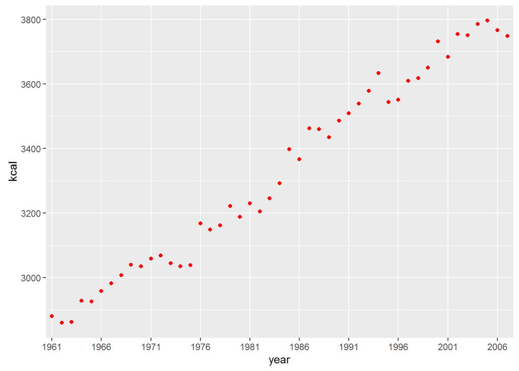

```r
# scale with range tick every 5 years

ggplot(aes(year, kcal), data=us) +
  geom_point(color='red') +
  scale_x_discrete(breaks=seq(1961, 2007, 5))
```

As expected it increases, but almost 3800 kcal per person?! We must be exporting most of our food right.

Are there any decreasing? Let’s check out some other countries:

```r
food[food$kcal==min(food$kcal[food$year==2007]),]
```

```
##                country year    kcal
## 11964 Congo, Dem. Rep. 2007 1605.08
```

So Democratic Republic of Congo produces least amount of food (in 2007) let’s look at the plot:

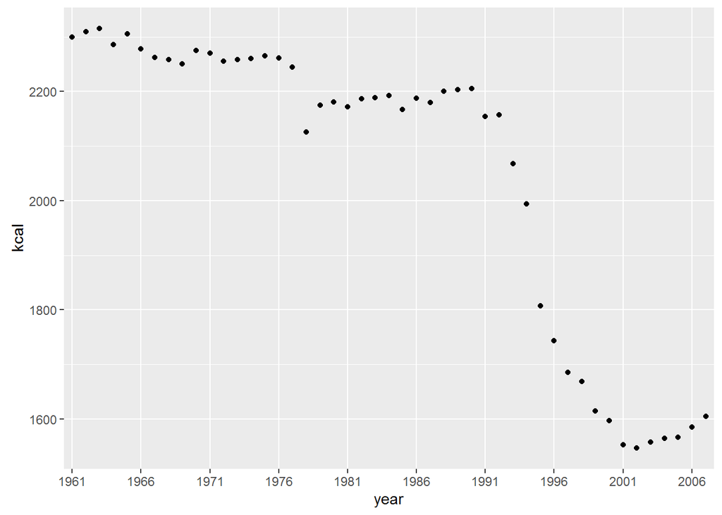

```r
congo = subset(food, food$country=='Congo, Dem. Rep.')
qplot(year, kcal, data=congo) +
  scale_x_discrete(breaks=seq(1961, 2007, 5))
```

Whoa! Huge drop off in the 90’s let’s check out why. [DR Congo wiki](https://en.wikipedia.org/wiki/Democratic_Republic_of_the_Congo) Sounds like US relations post cold war contributed and Mobutu became more currupt, leading to civil war, haven’t really recovered since.

Let’s try some more interesting plots with Plotly: borrowing a dataset with country codes and GDP

```r
library(plotly)
df <- read.csv('https://raw.githubusercontent.com/plotly/datasets/master/2014_world_gdp_with_codes.csv')
str(df)
```

```
## 'data.frame':    222 obs. of  3 variables:
##  $ COUNTRY       : Factor w/ 222 levels "Afghanistan",..: 1 2 3 4 5 6 7 8 9 10 ...
##  $ GDP..BILLIONS.: num  21.71 13.4 227.8 0.75 4.8 ...
##  $ CODE          : Factor w/ 221 levels "ABW","AFG","AGO",..: 2 5 57 10 6 3 4 11 8 9 ...
```

```r
colnames(df) = c('country', 'GDP_Billions', 'Country_Code')
```

set up parameters, boundaries and map options:

```r
# light grey boundaries
l <- list(color = toRGB("grey"), width = 0.5)

# specify map projection/options
g <- list(
  showframe = FALSE,
  showcoastlines = FALSE,
  projection = list(type = 'Mercator')
)
```

Before plotting need to join the two datasets

```r
x = merge(food, df, by='country', all.x = TRUE)#, all.y = TRUE)
subset(x, is.na(Country_Code) & year==2007)
```

```
##                   country year    kcal GDP_Billions Country_Code
## 365               Bahamas 2007 2712.50           NA         <NA>
## 1236           Cape Verde 2007 2571.92           NA         <NA>
## 1282 Central African Rep. 2007 1985.84           NA         <NA>
## 1563     Congo, Dem. Rep. 2007 1605.08           NA         <NA>
## 1603          Congo, Rep. 2007 2511.88           NA         <NA>
## 1830           Czech Rep. 2007 3260.34           NA         <NA>
## 2041       Dominican Rep. 2007 2295.10           NA         <NA>
## 2547               Gambia 2007 2384.59           NA         <NA>
## 3713     Korea, Dem. Rep. 2007 2087.04           NA         <NA>
## 3751          Korea, Rep. 2007 3073.71           NA         <NA>
## 4110       Macedonia, FYR 2007 3105.47           NA         <NA>
## 4706              Myanmar 2007 2464.91           NA         <NA>
## 4900 Netherlands Antilles 2007 3004.49           NA         <NA>
## 6101      Slovak Republic 2007 2892.60           NA         <NA>
## 7399   West Bank and Gaza 2007 2019.71           NA         <NA>
## 7449          Yemen, Rep. 2007 2067.57           NA         <NA>
```

Have a bunch of countries without country codes (‘NA’) let’s fix it:

```r
x$Country_Code[x$country=='Congo, Rep.'] = 'COG'
x$Country_Code[x$country=='Congo, Dem. Rep.'] = 'COD'
x$Country_Code[x$country=='Central African Rep.'] = 'CAF'
x$Country_Code[x$country=='Myanmar'] = 'MMR'
x$Country_Code[x$country=='Yemen, Rep.'] = 'YEM'
x$Country_Code[x$country=='Czech Rep.'] = 'CZE'
x$Country_Code[x$country=='Slovak Republic'] = 'SVK'
x$Country_Code[x$country=='West Bank and Gaza'] = 'WBG'
x$Country_Code[x$country=='Bahamas'] = 'BHM'
x$Country_Code[x$country=='Cape Verde'] = 'CPV'
x$Country_Code[x$country=='Dominican Rep.'] = 'DOM'
x$Country_Code[x$country=='Gambia'] = 'GMB'
x$Country_Code[x$country=='Korea, Dem. Rep.'] = 'KOR'
x$Country_Code[x$country=='Korea, Rep.'] = 'PRK'
x$Country_Code[x$country=='Macedonia, FYR'] = 'MKD'
#x$Country_Code[x$country=='Netherlands Antilles'] = 'ANT'
subset(x, is.na(Country_Code) & year==2007)
```

```
##                   country year    kcal GDP_Billions Country_Code
## 4900 Netherlands Antilles 2007 3004.49           NA         <NA>
```

Code for ‘Netherlands and Antilles’ is invalid so we’ll leave it out Let’s check out the map:

```r
plot_ly(x[x$year==2007,], z = kcal, text = country, locations = Country_Code, type = 'choropleth',
        color = kcal, colors = 'Purples', marker = list(line = l),
        colorbar = list(title = 'kcal/person')) %>%
  layout(title = 'food supply per person per day in kcals<br>(2007)',
         geo = g)
```

[interactive chart not shown]

We have some white holes in the map. Greenland, Afghanstan, and South Sudan all stick out as missing. Can add them so hovering over them at least shows country name:

```r
af = df[df$country=='Afghanistan',]
af$kcal = NA
af$year = 2007
x = rbind(x, af)

green = df[df$country=='Greenland',]
green$kcal=NA
green$year = 2007
x = rbind(x, green)

sud = df[df$country=='South Sudan',]
sud$kcal=NA
sud$year = 2007
x = rbind(x, sud)
```

Let’s check the map out again!

```r
plot_ly(x[x$year==2007,], z = kcal, text = country, locations = Country_Code, type = 'choropleth',
        color = kcal, colors = 'Purples', marker = list(line = l),
        colorbar = list(title = 'kcal/person')) %>%
  layout(title = 'food supply per person per day in kcals<br>(2007)',
         geo = g)
```

[interactive chart not shown]

There we go! That looks better. It follows what we would expect: richer countries produce more food. But most countries produce over 2000 kcals per day per person which is interesting. Let’s check out total production really quick.

```r
mean(x$kcal[x$year==2007], na.rm = TRUE)
```

```
## [1] 2756.14
```

So Average kcal production per person in 2007 was 2756. Let’s plot the averages:

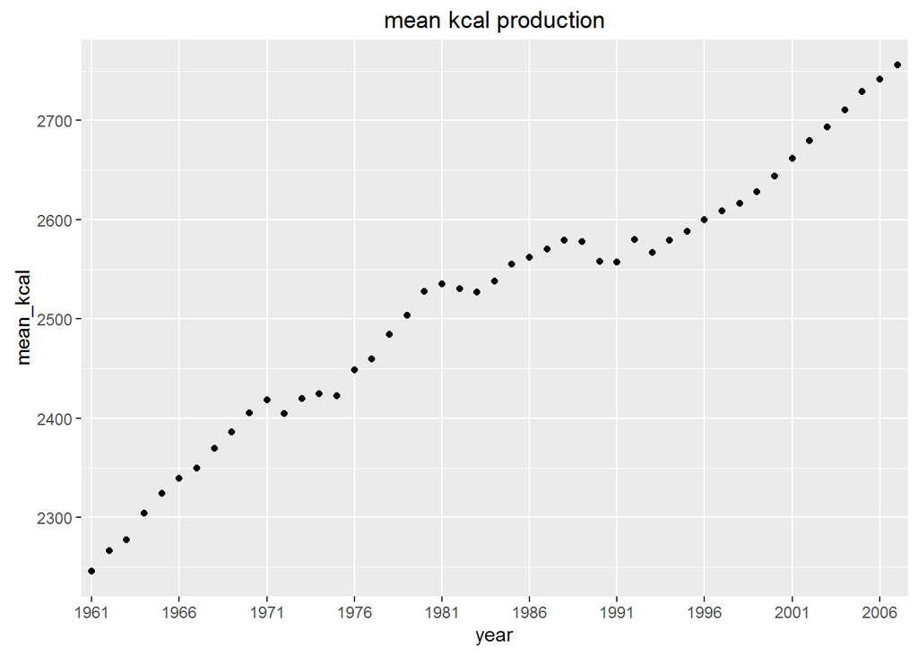

```r
means = aggregate(food$kcal, by=list(food$year), FUN='mean')
colnames(means) = c('year', 'mean_kcal')
qplot(year, mean_kcal, data=means,
      main = 'mean kcal production') +
  geom_point() +
  scale_x_discrete(breaks=seq(1961, 2007, 5))
```

Global production increasing linearly by about 500 kcal since 1961.

```r
means$mean_kcal[means$year==1961]
```

```
## [1] 2245.955
```

and we saw before 2007 mean was about 2756. In 2007 there were ~6.6 Billion people according to the internet, so total production:

```r
means$mean_kcal[means$year==2007]*6600000000
```

```
## [1] 1.819052e+13
```

that is 18.2 trillion kcals of food per DAY!